```python
%load_ext autoreload
%autoreload 2
%matplotlib inline
```

```python
import numpy as np
import matplotlib.pyplot as plt
from hottbox.core import Tensor
```

Return to Table of Contents

# Tensors and basic operations

[figure not shown]

A tensor is a multi-dimenaional array of data where each dimension is conventionally referred to as the **mode**. Tensor order is defined by the number of its modes which is equivivalent to the number of indices required to identify a particular entry of a multi-dimensional array. For ease of visualisation and compact notation, we consider a third order tensor $\mathbf{\underline{X}} \in \mathbb{R}^{I \times J \times K}$. Thus, an element of such a tensor, $\mathbf{\underline{X}} \in \mathbb{R}^{I \times J \times K}$, can be written in a general form as:

$$ x_{ijk} = \mathbf{\underline{X}}[i, j, k]$$

> **Note:** In order to be consistent with Python indexing, count of modes and elements within starts from zeros.

Creation of a tensor starts with a formation of a multidimensional array of data.

```python
# Create 3-d array of data
array_3d = np.arange(24).reshape((2, 3, 4))

# Create tensor
tensor = Tensor(array_3d)

# Result preview
print(tensor)
tensor.data
```

```
This tensor is of order 3 and consists of 24 elements.
Sizes and names of its modes are (2, 3, 4) and ['mode-0', 'mode-1', 'mode-2'] respectively.
```

```
array([[[ 0,  1,  2,  3],
        [ 4,  5,  6,  7],
        [ 8,  9, 10, 11]],

       [[12, 13, 14, 15],
        [16, 17, 18, 19],
        [20, 21, 22, 23]]])
```

## **Assigment 1**

1. Create a tensor of order 5 (of any shape) and with all its values equal to 5. Then, calculate its Frobenious norm.
2. Construct several tensors of orders varying from 3 to 20, with the size of each dimension equal to 2. Plot the relation between an order of a tensor and the number of its elements.
3. Construct several tensors of order 3 with the size of each dimension varying from 3 to 15. Plot the relation between the size of dimensions of a tensor and the number of its elements.
4. Analyse and compare the so obtained graphs.

### Solution: Part 1

```python
# Create a tensor
array5D = 5*np.ones((2,3,2,3,2))
tensor = Tensor(array5D)
```

```python
# Calculate Frobenious norm
norm = tensor.frob_norm
norm
```

```
42.42640687119285
```

### Solution: Part 2

```python
# Create tensors and collect information
order = np.zeros((10,))
elemNum = np.zeros((10,))
tensor3 = Tensor(np.arange(2**3).reshape((2,2,2)))
order[0] = tensor3.order
elemNum[0] = tensor3.size
tensor5 = Tensor(np.arange(2**5).reshape((2,2,2,2,2)))
order[1] = tensor5.order
elemNum[1] = tensor5.size
tensor7 = Tensor(np.arange(2**7).reshape((2,2,2,2,2,2,2)))
order[2] = tensor7.order
elemNum[2] = tensor7.size
tensor9 = Tensor(np.arange(2**9).reshape((2,2,2,2,2,2,2,2,2)))
order[3] = tensor9.order
elemNum[3] = tensor9.size
tensor11 = Tensor(np.arange(2**11).reshape((2,2,2,2,2,2,2,2,2,2,2)))
order[4] = tensor11.order
elemNum[4] = tensor11.size
tensor13 = Tensor(np.arange(2**13).reshape((2,2,2,2,2,2,2,2,2,2,2,2,2)))
order[5] = tensor13.order
elemNum[5] = tensor13.size
tensor15 = Tensor(np.arange(2**15).reshape((2,2,2,2,2,2,2,2,2,2,2,2,2,2,2)))
order[6] = tensor15.order
elemNum[6] = tensor15.size
tensor17 = Tensor(np.arange(2**17).reshape((2,2,2,2,2,2,2,2,2,2,2,2,2,2,2,2,2)))
order[7] = tensor17.order
elemNum[7] = tensor17.size
tensor19 = Tensor(np.arange(2**19).reshape((2,2,2,2,2,2,2,2,2,2,2,2,2,2,2,2,2,2,2)))
order[8] = tensor19.order
elemNum[8] = tensor19.size
tensor20 = Tensor(np.arange(2**20).reshape((2,2,2,2,2,2,2,2,2,2,2,2,2,2,2,2,2,2,2,2)))
order[9] = tensor20.order
elemNum[9] = tensor20.size
```

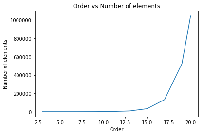

```python
# Plot results
plt.plot(order,elemNum)
plt.xlabel('Order')
plt.ylabel('Number of elements')
plt.title('Order vs Number of elements')
```

### Solution: Part 3

```python
# Create tensors and collect information
dim = np.zeros((7,))
elemNum = np.zeros((7,))

tensor3 = Tensor(np.arange(3**3).reshape((3,3,3)))
dim[0] = tensor3.shape[0]
elemNum[0] = tensor3.size
tensor5 = Tensor(np.arange(5**3).reshape((5,5,5)))
dim[1] = tensor5.shape[0]
elemNum[1] = tensor5.size
tensor7 = Tensor(np.arange(7**3).reshape((7,7,7)))
dim[2] = tensor7.shape[0]
elemNum[2] = tensor7.size
tensor9 = Tensor(np.arange(9**3).reshape((9,9,9)))
dim[3] = tensor9.shape[0]
elemNum[3] = tensor9.size
tensor11 = Tensor(np.arange(11**3).reshape((11,11,11)))
dim[4] = tensor11.shape[0]
elemNum[4] = tensor11.size
tensor13 = Tensor(np.arange(13**3).reshape((13,13,13)))
dim[5] = tensor13.shape[0]
elemNum[5] = tensor13.size
tensor15 = Tensor(np.arange(15**3).reshape((15,15,15)))
dim[6] = tensor15.shape[0]
elemNum[6] = tensor15.size
```

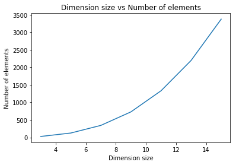

```python
# Plot results
plt.plot(dim,elemNum)
plt.xlabel('Dimension size')
plt.ylabel('Number of elements')
plt.title('Dimension size vs Number of elements')
```

### Solution: Part 4

Increasing order thus has a much bigger effect in the number of elements than increasing dimension, as the exponential increases more rapidly than the polynomial.

# Most common tensor substructures

[figure not shown]

**Note:** The same principles and definitions can be applied to a tensor of an arbitrarily large order. In addition, you can obtain a **subtensor** by fixing at least three indices and letting the remaining ones vary.

```python
# Mode-2 fiber
tensor.data[0,1,:]
```

```
array([[[5., 5.],
        [5., 5.],
        [5., 5.]],

       [[5., 5.],
        [5., 5.],
        [5., 5.]]])
```

```python
# Frontal slice
tensor.data[0,:,:]
```

```
array([[[[5., 5.],
         [5., 5.],
         [5., 5.]],

        [[5., 5.],
         [5., 5.],
         [5., 5.]]],


       [[[5., 5.],
         [5., 5.],
         [5., 5.]],

        [[5., 5.],
         [5., 5.],
         [5., 5.]]],


       [[[5., 5.],
         [5., 5.],
         [5., 5.]],

        [[5., 5.],
         [5., 5.],
         [5., 5.]]]])
```

## **Assigment 2**

1. Create a tensor of order 4 which consists of 81 elements and display all its horizontal slices and any five row fibers.
2. Create a tensor of order 3 and shape `(4,2,5)`, where the values of each consequent frontal slice are doubled.

### Solution: Part 1

```python
# Create a tensor of order 4
tensor = Tensor(np.arange(81).reshape((3,3,3,3)))
```

```python
# Display slices
for j in range(3):
    for i in range(3):
        print(tensor.data[j,:,:,i])
```

```
[[ 0  3  6]
 [ 9 12 15]
 [18 21 24]]
[[ 1  4  7]
 [10 13 16]
 [19 22 25]]
[[ 2  5  8]
 [11 14 17]
 [20 23 26]]
[[27 30 33]
 [36 39 42]
 [45 48 51]]
[[28 31 34]
 [37 40 43]
 [46 49 52]]
[[29 32 35]
 [38 41 44]
 [47 50 53]]
[[54 57 60]
 [63 66 69]
 [72 75 78]]
[[55 58 61]
 [64 67 70]
 [73 76 79]]
[[56 59 62]
 [65 68 71]
 [74 77 80]]
```

```python
# Display fibers
print(tensor.data[0,:,0,0])
print(tensor.data[0,:,0,1])
print(tensor.data[0,:,0,2])
print(tensor.data[0,:,1,0])
print(tensor.data[0,:,1,1])
```

```
[ 0  9 18]
[ 1 10 19]
[ 2 11 20]
[ 3 12 21]
[ 4 13 22]
```

### Solution: Part 2

```python
# Create a tensor of order 3
tensor = Tensor(np.ones(40).reshape((4,2,5)))
for i in range(4):
    tensor.data[:,:,i+1] = 2*tensor.data[:,:,i]

tensor.data
```

```
array([[[ 1.,  2.,  4.,  8., 16.],
        [ 1.,  2.,  4.,  8., 16.]],

       [[ 1.,  2.,  4.,  8., 16.],
        [ 1.,  2.,  4.,  8., 16.]],

       [[ 1.,  2.,  4.,  8., 16.],
        [ 1.,  2.,  4.,  8., 16.]],

       [[ 1.,  2.,  4.,  8., 16.],
        [ 1.,  2.,  4.,  8., 16.]]])
```

# Unfolding

Conventionally, unfolding is considered to be a process of element mapping from a tensor to a matrix. In other words, it arranges the mode-$n$ fibers of a tensor to be the matrix columns. Thus, the mode-$n$ unfolding is denoted as:

$$\mathbf{\underline{A}} \xrightarrow{n} \mathbf{A}_{(n)}$$

Thus, this operations requires to specify a mode along which a tensor will be unfolded. For a third order tensor, a visual representation of such operation is as following

[figure not shown]

In `hottbox` this functionality is available through the corresponding methods of the `Tensor` object, for instance:

```python
# Create 3-d array of data
array_3d = np.arange(24).reshape((2, 3, 4))

# Create tensor
tensor = Tensor(array_3d)

# Unfolding of a tensor
tensor.unfold(mode=0)

# Result preview
print(tensor)
tensor.data
```

```
This tensor is of order 2 and consists of 24 elements.
Sizes and names of its modes are (2, 12) and ['mode-0', 'mode-1_mode-2'] respectively.
```

```
array([[ 0,  1,  2,  3,  4,  5,  6,  7,  8,  9, 10, 11],
       [12, 13, 14, 15, 16, 17, 18, 19, 20, 21, 22, 23]])
```

## **Assigment 3**

1. Create a tensor, $\mathbf{\underline{A}}$, of order 4, in such a way that its version unfolded along the second mode would have sizes `(5,72)`, that is $\mathbf{A}_{(n)} \in \mathbb{R}^{5 \times 72}$. Validate your results by displaying the unfolded tensor.

### Solution : Part 1

```python
# Create a tensor
A = Tensor(np.arange(360).reshape((2,5,6,6)))
A
```

```
This tensor is of order 4 and consists of 360 elements.
Sizes and names of its modes are (2, 5, 6, 6) and ['mode-0', 'mode-1', 'mode-2', 'mode-3'] respectively.
```

```python
# Display unfolded version
A.unfold(mode=1)
print(A)
A.data
```

```
This tensor is of order 2 and consists of 360 elements.
Sizes and names of its modes are (5, 72) and ['mode-1', 'mode-0_mode-2_mode-3'] respectively.
```

```
array([[  0,   1,   2,   3,   4,   5,   6,   7,   8,   9,  10,  11,  12,
         13,  14,  15,  16,  17,  18,  19,  20,  21,  22,  23,  24,  25,
         26,  27,  28,  29,  30,  31,  32,  33,  34,  35, 180, 181, 182,
        183, 184, 185, 186, 187, 188, 189, 190, 191, 192, 193, 194, 195,
        196, 197, 198, 199, 200, 201, 202, 203, 204, 205, 206, 207, 208,
        209, 210, 211, 212, 213, 214, 215],
       [ 36,  37,  38,  39,  40,  41,  42,  43,  44,  45,  46,  47,  48,
         49,  50,  51,  52,  53,  54,  55,  56,  57,  58,  59,  60,  61,
         62,  63,  64,  65,  66,  67,  68,  69,  70,  71, 216, 217, 218,
        219, 220, 221, 222, 223, 224, 225, 226, 227, 228, 229, 230, 231,
        232, 233, 234, 235, 236, 237, 238, 239, 240, 241, 242, 243, 244,
        245, 246, 247, 248, 249, 250, 251],
       [ 72,  73,  74,  75,  76,  77,  78,  79,  80,  81,  82,  83,  84,
         85,  86,  87,  88,  89,  90,  91,  92,  93,  94,  95,  96,  97,
         98,  99, 100, 101, 102, 103, 104, 105, 106, 107, 252, 253, 254,
        255, 256, 257, 258, 259, 260, 261, 262, 263, 264, 265, 266, 267,
        268, 269, 270, 271, 272, 273, 274, 275, 276, 277, 278, 279, 280,
        281, 282, 283, 284, 285, 286, 287],
       [108, 109, 110, 111, 112, 113, 114, 115, 116, 117, 118, 119, 120,
        121, 122, 123, 124, 125, 126, 127, 128, 129, 130, 131, 132, 133,
        134, 135, 136, 137, 138, 139, 140, 141, 142, 143, 288, 289, 290,
        291, 292, 293, 294, 295, 296, 297, 298, 299, 300, 301, 302, 303,
        304, 305, 306, 307, 308, 309, 310, 311, 312, 313, 314, 315, 316,
        317, 318, 319, 320, 321, 322, 323],
       [144, 145, 146, 147, 148, 149, 150, 151, 152, 153, 154, 155, 156,
        157, 158, 159, 160, 161, 162, 163, 164, 165, 166, 167, 168, 169,
        170, 171, 172, 173, 174, 175, 176, 177, 178, 179, 324, 325, 326,
        327, 328, 329, 330, 331, 332, 333, 334, 335, 336, 337, 338, 339,
        340, 341, 342, 343, 344, 345, 346, 347, 348, 349, 350, 351, 352,
        353, 354, 355, 356, 357, 358, 359]])
```

# Mode-n product

[figure not shown]

The mode-$n$ product is a multiplication of a tensor by a matrix along the $n^{th}$ mode of a tensor. This essentially means that each mode-$n$ fiber should be multiplied by this matrix. Mathematically, this can be expressed as:

$$\mathbf{\underline{X}} \times_n \mathbf{A} = \mathbf{\underline{Y}} \quad \Leftrightarrow \quad \mathbf{Y}_{(n)} = \mathbf{A} \mathbf{X}_{(n)} $$

```python
I, J, K = 2, 3, 4
J_new = 5

# Create tensor
array_3d = np.arange(I * J * K).reshape(I, J ,K)
X = Tensor(array_3d)

# Create matrix
A = np.arange(J_new * J).reshape(J_new, J)

# Performs Mode-n product
Y = X.mode_n_product(A, mode=1, inplace=False)

# Preview of resulting tensor
print(Y)

# Preview of its unfolded version
Y.unfold(mode=1, inplace=False).data
```

```
This tensor is of order 3 and consists of 40 elements.
Sizes and names of its modes are (2, 5, 4) and ['mode-0', 'mode-1', 'mode-2'] respectively.
```

```
array([[ 20,  23,  26,  29,  56,  59,  62,  65],
       [ 56,  68,  80,  92, 200, 212, 224, 236],
       [ 92, 113, 134, 155, 344, 365, 386, 407],
       [128, 158, 188, 218, 488, 518, 548, 578],
       [164, 203, 242, 281, 632, 671, 710, 749]])
```

## **Assignment 4**

1. Perform the mode-$n$ product of a 3-rd order tensor, $\mathbf{\underline{X}}$, with a matrix, $\mathbf{A} \in \mathbb{R}^{5 \times 4}$, provided that the resulting tensor, $\mathbf{\underline{Y}}$, consists of `100` elements. Validate your results.

> **Note:** You are encouraged to experiment with the optional parameter `inplace` and to investigate its effect on the result.

### Solution: Part 1

```python
# Create original tensor
X = Tensor(np.arange(80).reshape((10,2,4)))
```

```python
# Create matrix
A = np.arange(20).reshape((5,4))
```

```python
# Perform mode-n product
Y = X.mode_n_product(A, mode=2, inplace=False)
Y
```

```
This tensor is of order 3 and consists of 100 elements.
Sizes and names of its modes are (10, 2, 5) and ['mode-0', 'mode-1', 'mode-2'] respectively.
```

```python
# Validate equivalence between the left and right hand side
print(Y.data[0,0,:]) # values in Y
print(np.matmul(X.data[0,0,:],A.T))  # result from matrix multiplication
```

```
[ 14  38  62  86 110]
[ 14  38  62  86 110]
```

# Properties of mode-n product

1. For distinct modes in a series of multiplications, the order of the multiplication is irrelevent:

   $$\mathbf{\underline{X}} \times_n \mathbf{A} \times_m \mathbf{B} = \mathbf{\underline{X}} \times_m \mathbf{B} \times_n \mathbf{A} \quad (m \neq n)$$
2. However, this does not hold if the modes are the same :

   $$\mathbf{\underline{X}} \times_n \mathbf{A} \times_n \mathbf{B} = \mathbf{\underline{X}} \times_n (\mathbf{B}\mathbf{A})$$

## **Assignment 5**

1. Validate both of the above properties empirically
2. Prove the second property analytically

> **Note:** Be aware of consequences of the optional parameter `inplace` (its default value is set to `True`).

### Solution: Part 1

```python
# Create tensor
X = Tensor(np.arange(24).reshape((2,3,4)))
```

```python
# Create matrices
A = np.arange(12).reshape((4,3))
B = np.arange(12).reshape((3,4))
```

```python
# Validate property 1
Y1 = X.mode_n_product(A, mode=1, inplace=False).mode_n_product(B, mode=2, inplace=False)
Y2 = X.mode_n_product(B, mode=2, inplace=False).mode_n_product(A, mode=1, inplace=False)
np.array_equal(Y1.data,Y2.data)
```

```
True
```

```python
# Validate property 2
Y3 = X.mode_n_product(A,mode=1, inplace=False).mode_n_product(B,mode=1, inplace=False)
Y4 = X.mode_n_product(np.matmul(B,A), mode=1, inplace=False)

np.array_equal(Y3.data,Y4.data)
```

```
True
```

### Solution: Part 2

Use [LaTeX syntax](https://stackoverflow.com/questions/13208286/how-to-write-latex-in-ipython-notebook) for analytical deriviations for the second property below.

```python
%%latex
In mode-n product a series of multiplications is commutative only if modes are different. If modes are the same the below equation holds:

        $$\underline{\mathbf{X}} \times_n \mathbf{A} \times_n \mathbf{B} = \underline{\mathbf{X}} \times_n (\mathbf{BA})$$

To prove this we have to consider the mode-n product as the matrix multiplications that it entails, that is considering the tensor as a set of stacked matrices.

If we ignore $\mathbf{B}$ for now, the tensor will be modified in one of its dimensions, in which the matrix operation below occurs:

        $$\mathbf{A} \times \mathbf{X}_i = \mathbf{\hat{X}}_i$$

where $\mathbf{X}_i$ is a slice of the tensor, and then:

        $$\mathbf{B} \times \mathbf{\hat{X}}_i = \mathbf{\bar{X}}_i$$

We can observe then how if the $n$ mode is selected of size 3 and the sizes of $\mathbf{A,B}$ are $(4\times3),(6\times4)$, the end size of the tensor dimension is 6, $3\rightarrow 4\rightarrow 6$.
We thus would have the equivalent of multiplying by a matrix of $(6\times3)$. The mode-n product is effectively performing a multiplication from the front of the matrices and so the equivalent matrix multiplication would be:

        $$\mathbf{B} \times \mathbf{A} \times \mathbf{X}_i = \mathbf{\bar{X}}_i$$

Which is equivalent to the first equation where $\mathbf{B} \times \mathbf{A} = \mathbf{BA}$. The concept is easy to understand if we realise the operation is simply matrix multiplications and that since for the sequence of multiplications $\mathbf{B}$ is after $\mathbf{A}$, $\mathbf{B}$ is performing the multiplication on the results of the multplication of $\mathbf{AX$_i.
```

In mode-n product a series of multiplications is commutative only if modes are different. If modes are the same the below equation holds: $$\underline{\mathbf{X}} \times_n \mathbf{A} \times_n \mathbf{B} = \underline{\mathbf{X}} \times_n (\mathbf{BA})$$ To prove this we have to consider the mode-n product as the matrix multiplications that it entails, that is considering the tensor as a set of stacked matrices. If we ignore $\mathbf{B}$ for now, the tensor will be modified in one of its dimensions, in which the matrix operation below occurs: $$\mathbf{A} \times \mathbf{X}_i = \mathbf{\hat{X}}_i$$ where $\mathbf{X}_i$ is a slice of the tensor, and then: $$\mathbf{B} \times \mathbf{\hat{X}}_i = \mathbf{\bar{X}}_i$$ We can observe then how if the $n$ mode is selected of size 3 and the sizes of $\mathbf{A,B}$ are $(4\times3),(6\times4)$, the end size of the tensor dimension is 6, $3\rightarrow 4\rightarrow 6$. We thus would have the equivalent of multiplying by a matrix of $(6\times3)$. The mode-n product is effectively performing a multiplication from the front of the matrices and so the equivalent matrix multiplication would be: $$\mathbf{B} \times \mathbf{A} \times \mathbf{X}_i = \mathbf{\bar{X}}_i$$ Which is equivalent to the first equation where $\mathbf{B} \times \mathbf{A} = \mathbf{BA}$. The concept is easy to understand if we realise the operation is simply matrix multiplications and that since for the sequence of multiplications $\mathbf{B}$ is after $\mathbf{A}$, $\mathbf{B}$ is performing the multiplication on the results of the multplication of $\mathbf{AX$_i.